# Przygotowanie i walidacja danych

# Przykładowe wykresy pomiędzy zmiennymi

Przeprowadzimy teraz wizualizację niektórych zależności z naszego zbioru, sugerowaliśmy się poziomem korelacji, dlatego zaczynamy od zmiennych, które wcześniej wyszły nam silnie od siebie zależne.

**Forest_area** -> **TLAXX**

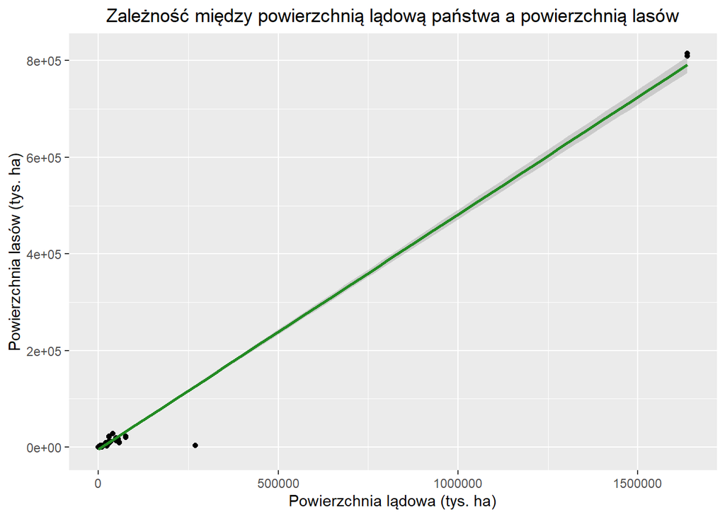

```r
ggplot(forest_gdp_db, aes(x = TLAXX, y = Forest_area)) +
  geom_point() + # rysuje wykres punktowy
  # rysuje linię trendu dopasowaną metodą regresji liniowej (lm)
  geom_smooth(method = "lm", col = 'forestgreen', na.rm = T) +
  xlab("Powierzchnia lądowa (tys. ha)") + ylab("Powierzchnia lasów (tys. ha)") +
  ggtitle("Zależność między powierzchnią lądową państwa a powierzchnią lasów") +
  theme(plot.title = element_text(hjust = 0.5)) # umieszcza tytuł wykresu na środku
```

Sprawdziliśmy zależności między powierzchnią lądową (**TLAXX**) a powierzchnią leśną (**Forest_area**) i zauważamy bardzo duże obserwacje odstające, które przeszkadzają nam w badaniu. Skoro porównujemy dane związane z powierzchnią państwa, podejrzewamy, że tą obserwacją może być największe państwo na świecie, czyli Rosja, zatem wykonajmy wykres bez Rosji.

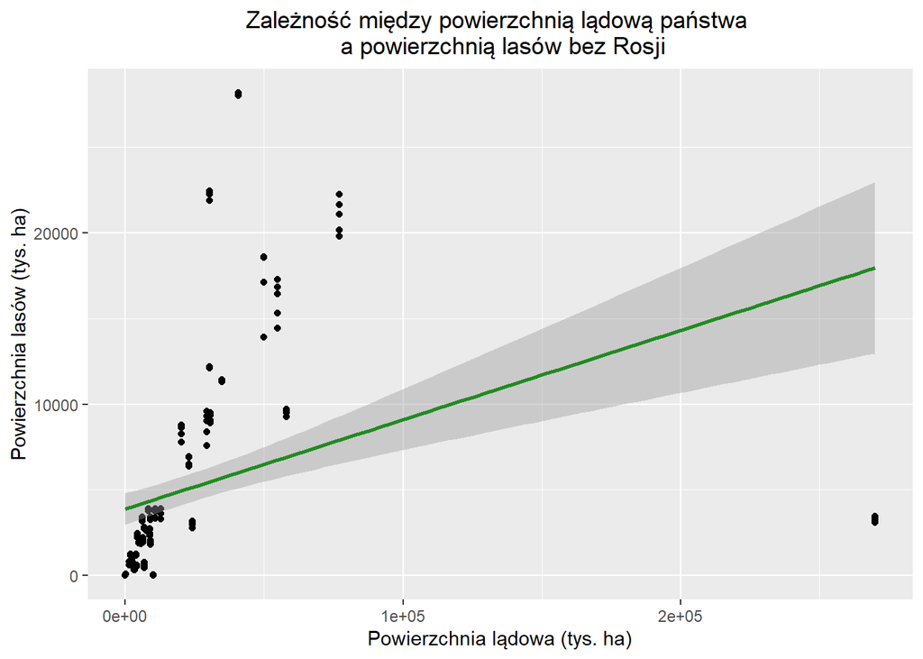

```r
ggplot(forest_gdp_db[forest_gdp_db$Country != "Russian Federation",], aes(x = TLAXX, y = Forest_area)) +
  geom_point() +
  geom_smooth(method = "lm", col = 'forestgreen', na.rm = T) +
  xlab("Powierzchnia lądowa (tys. ha)") + ylab("Powierzchnia lasów (tys. ha)") +
  ggtitle("Zależność między powierzchnią lądową państwa \n a powierzchnią lasów bez Rosji") +
  theme(plot.title = element_text(hjust = 0.5))
```

Widzimy delikatną poprawę, ale zauważamy kolejną obserwację odstającą, czyli prawdopodobnie w naszych danych będzie to kolejne duże państwo, mianowicie Kazachstan, zatem wykonajmy wykres jeszcze raz, tym razem bez Rosji i Kazachstanu. Dodatkowo sprawdzamy jak rozkładają się dane pod względem poziomu lesistości (**PLAS**) i poziomu rozwoju gospodarczego (**PRG**).

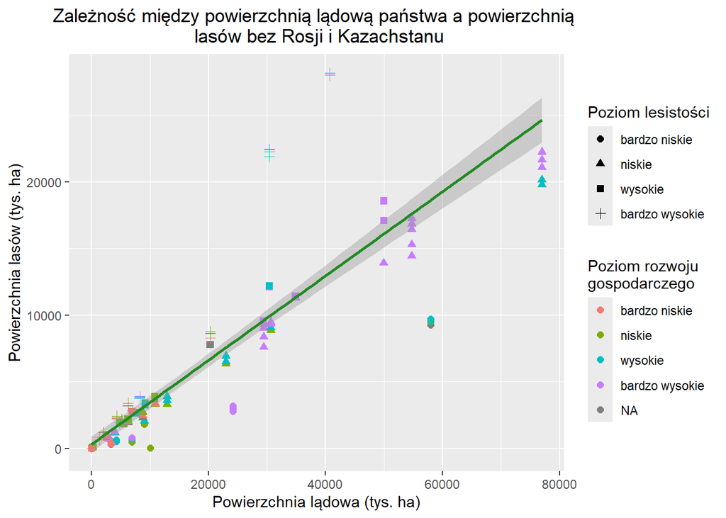

```r
ggplot(forest_gdp_db[forest_gdp_db$Country != "Russian Federation" & forest_gdp_db$Country != "Kazakhstan",],
       aes(TLAXX, Forest_area)) +
  geom_point(aes(col = PRG, shape = PLAS), size = 2) +
  geom_smooth(method = "lm", col = 'forestgreen', na.rm = T) +
  xlab("Powierzchnia lądowa (tys. ha)") + ylab("Powierzchnia lasów (tys. ha)") +
  ggtitle("Zależność między powierzchnią lądową państwa a powierzchnią \n lasów bez Rosji i Kazachstanu") +
  theme(plot.title = element_text(hjust = 0.5)) +
  labs(color = "Poziom rozwoju \ngospodarczego", shape = "Poziom lesistości")
```

Widzimy, że bez Rosji i Kazachstanu wykres wygląda znacząco lepiej, zatem Rosja i Kazachstan są potencjalnymi obserwacji odstającymi. Widzimy również, że kraje o wysokim poziomie PKB mają raczej większą powierzchnię lądową. Co ciekawe widzimy, że państwa o dużej powierzchni lądowej mają raczej niski procent powierzchni leśnej.

**EFV** -> **TLAXX**

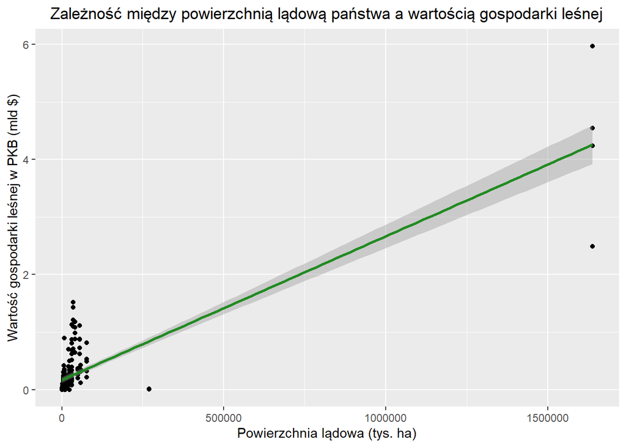

```r
ggplot(forest_gdp_db, aes(x = TLAXX, y = EFV)) +
  geom_point() +
  geom_smooth(method = "lm", col = "forestgreen", na.rm = T) +
  xlab("Powierzchnia lądowa (tys. ha)") + ylab("Wartość gospodarki leśnej w PKB (mld $)") +
  ggtitle("Zależność między powierzchnią lądową państwa a wartością gospodarki leśnej") +
  theme(plot.title = element_text(hjust = 0.5))
```

W przypadku wartości gospodarki leśnej w PKB (**EFV**) i powierzchni lądowej (**TLAXX**) znowu widzimy potencjalne obserwacje odstające, na podstawie wcześniejszej analizy domyślamy się, że jest to Rosja oraz Kazachstan, zatem wykonamy wykres bez tych państw i dodatkowo przeanalizujemy nasze wyniki pod względem poziomu lesistości (**PLAS**) i poziomu rozwoju gospodarczego (**PRG**).

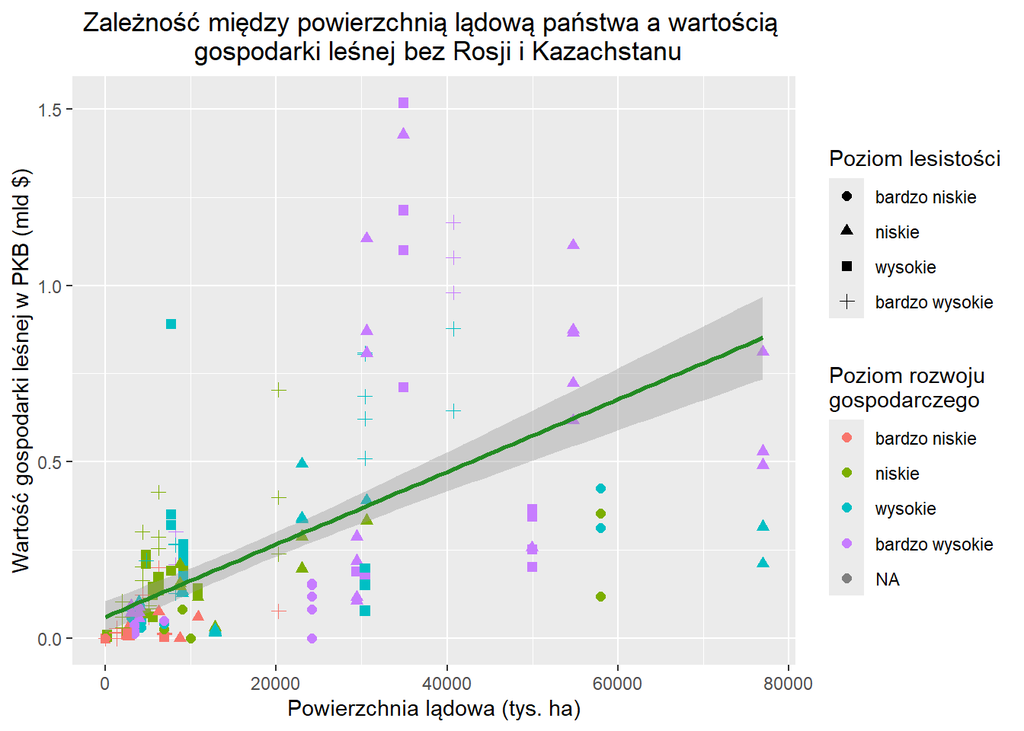

```r
ggplot(forest_gdp_db[forest_gdp_db$Country != "Russian Federation" & forest_gdp_db$Country != "Kazakhstan", ],
       aes(TLAXX, EFV)) +
  geom_point(aes(col = PRG, shape = PLAS), size = 2) +
  geom_smooth(method = "lm", col = "forestgreen", na.rm = T) +
  xlab("Powierzchnia lądowa (tys. ha)") + ylab("Wartość gospodarki leśnej w PKB (mld $)") +
  ggtitle("Zależność między powierzchnią lądową państwa a wartością \n gospodarki leśnej bez Rosji i Kazachstanu")  +
  theme(plot.title = element_text(hjust = 0.5)) +
  labs(color = "Poziom rozwoju \ngospodarczego", shape = "Poziom lesistości")
```

Widzimy, że zdecydowanie nie mamy tutaj zależności liniowej. Dzięki wprowadzeniu dodatkowych zmiennych do wykresu zauważamy, że państwa o większej powierzchni lądowej mają również wyższy poziom rozwoju gospodarczego, ale niekoniecznie wysoki procent powierzchni leśnej. Z kolei państwa o wysokiej wartości godpsodarki leśnej w PKB (**EFV**) mają także wysoki procent powierzchni leśnej i bardzo wysoki poziom gospodarczy.

**EFV** -> **Forest_area**

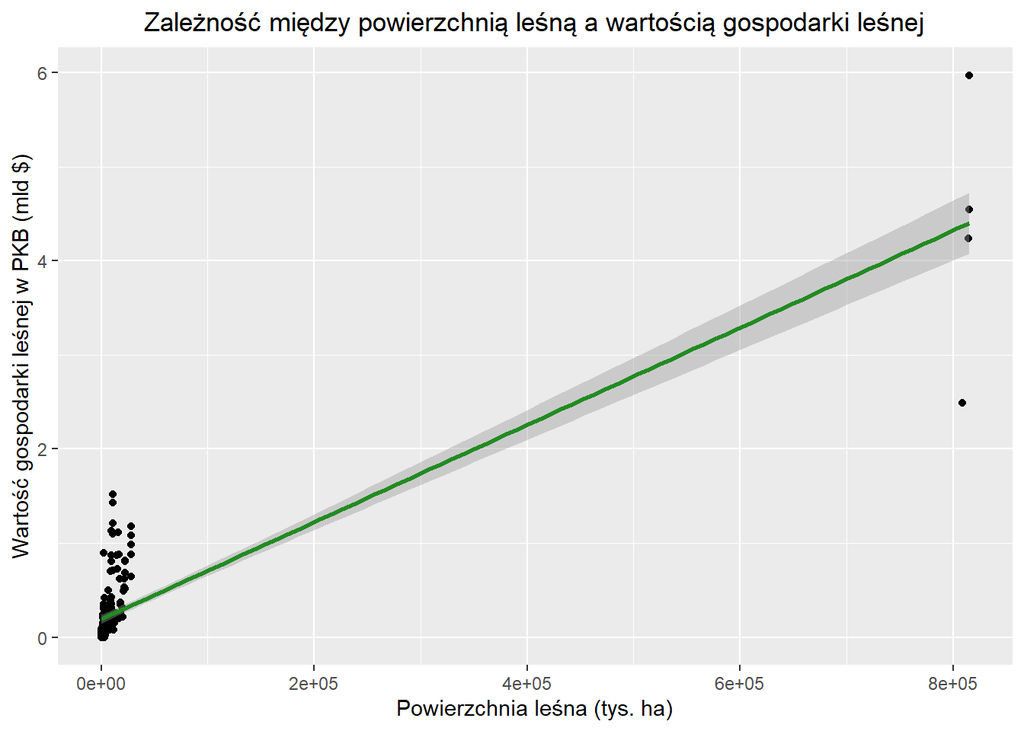

```r
ggplot(forest_gdp_db, aes(x = Forest_area, y = EFV)) +
  geom_point() +
  geom_smooth(method = "lm", col = "forestgreen", na.rm = TRUE) +
  xlab("Powierzchnia leśna (tys. ha)") + ylab("Wartość gospodarki leśnej w PKB (mld $)") +
  ggtitle("Zależność między powierzchnią leśną a wartością gospodarki leśnej")  +
  theme(plot.title = element_text(hjust = 0.5))
```

Ponownie widzimy potencjalne obserwacje odstające utrudniające analizę, zatem wykonajmy wykres jeszcze raz, ale bez Rosji, która ma stosunkowo dużą powierzchnię leśną i dodatkowo przeanalizujemy nasze wyniki pod względem poziomu lesistości (**PLAS**) i poziomu rozwoju gospodarczego (**PRG**).

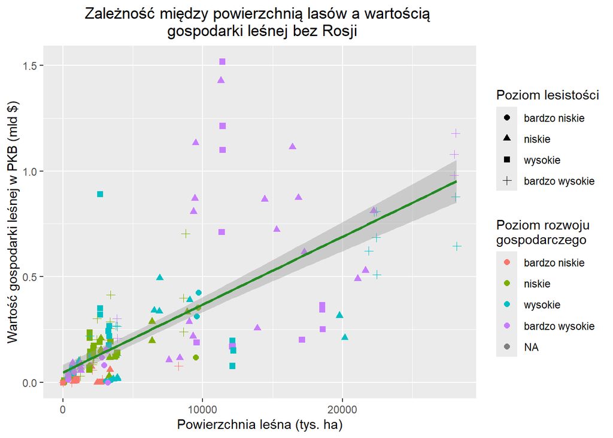

```r
ggplot(forest_gdp_db[forest_gdp_db$Country != "Russian Federation", ], aes(x = Forest_area, y = EFV)) +
  geom_point(aes(col = PRG, shape = PLAS), size = 2) +
  geom_smooth(method = "lm", col = "forestgreen", na.rm = TRUE) +
  xlab("Powierzchnia leśna (tys. ha)") + ylab("Wartość gospodarki leśnej w PKB (mld $)") +
  ggtitle("Zależność między powierzchnią lasów a wartością \n gospodarki leśnej bez Rosji") +
  theme(plot.title = element_text(hjust = 0.5)) +
  labs(color = "Poziom rozwoju \ngospodarczego", shape = "Poziom lesistości")
```

Widzimy, że między powierzchnią leśną (**Forest_area**) a wartością gospodarki leśnej w PKB (**EFV**) nie ma zależności liniowej. Państwa o największej powierzchni leśnej mają wysoki lub bardzo wysoki poziom PKB oraz wysoki procentowy udział lasów. Państwa o małej powierzchni leśnej mają niskie PKB i niewielką procentową powierzchnię lasów.

Przechodzimy teraz do analizy zmiennych umiarkowanie od siebie zależnych.

**%GDP** -> **AFPTLA**

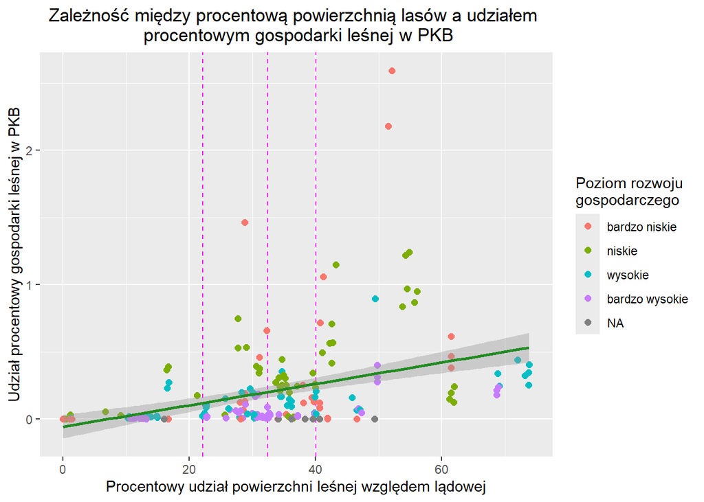

```r
kwartyle_AFPTLA <- c(
  quantile(forest_gdp_db$AFPTLA, 0.25, na.rm = TRUE),
  quantile(forest_gdp_db$AFPTLA, 0.5, na.rm = TRUE),
  quantile(forest_gdp_db$AFPTLA, 0.75, na.rm = TRUE)
)

ggplot(forest_gdp_db, aes(x = `AFPTLA`, y = `%GDP`)) +
  # dodaje linie reprezentujące kwartyle
  geom_vline(xintercept = kwartyle_AFPTLA, color = "magenta", linetype = "dashed") +
  geom_point(aes(col = PRG), size = 2) +
  geom_smooth(method = "lm", col = "forestgreen", na.rm = TRUE) +
  xlab("Procentowy udział powierzchni leśnej względem lądowej") +
  ylab("Udział procentowy gospodarki leśnej w PKB") +
  ggtitle("Zależność między procentową powierzchnią lasów a udziałem \n procentowym gospodarki leśnej w PKB") +
  theme(plot.title = element_text(hjust = 0.5)) +
  labs(color = "Poziom rozwoju \ngospodarczego")
```

Mamy duży rozrzut punktów, dlatego dopasowanie liniowe nie jest tutaj dobrym pomysłem. Nie ma też wyraźnej zależności pomiędzy procentowym udziałem powierzchni leśnej a poziomem PKB kraju. Pionowymi liniami zaznaczone zostały kwartyle Q1, Q2 i Q3 dla procentowego udziału powierzchni leśnej względem lądowej (**AFPTLA**). Pomiędzy 20% a 40% powierzchni leśnej znajduje się 50% wszystkich danych.

Sprawdźmy również zależności między zmiennymi o słabej korelacji.

**%GDP** -> **GDP** (-)

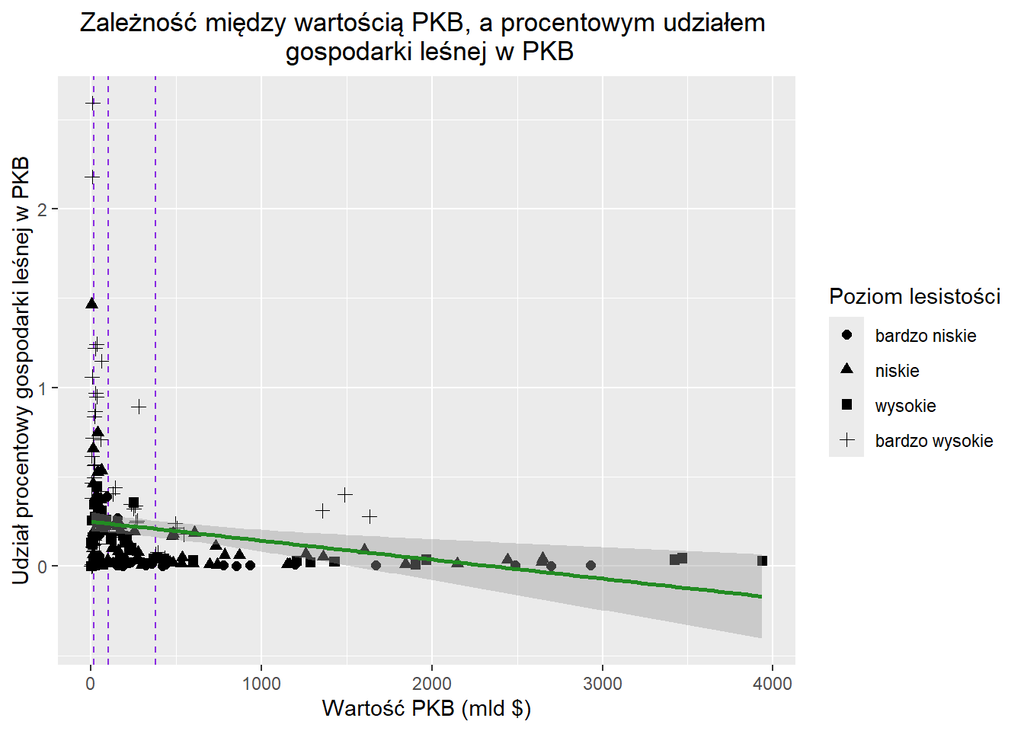

```r
kwartyle_GDP <- c(
  quantile(forest_gdp_db$GDP, 0.25, na.rm = TRUE),
  quantile(forest_gdp_db$GDP, 0.5, na.rm = TRUE),
  quantile(forest_gdp_db$GDP, 0.75, na.rm = TRUE)
)
ggplot(forest_gdp_db, aes(x = `GDP`, y = `%GDP`)) +
  geom_vline(xintercept = kwartyle_GDP, col = "blueviolet", linetype = "dashed") +
  geom_point(aes(shape = PLAS), size = 2) +
  geom_smooth(method = "lm", col = "forestgreen", na.rm = TRUE) +
  xlab("Wartość PKB (mld $)") + ylab("Udział procentowy gospodarki leśnej w PKB") +
  ggtitle("Zależność między wartością PKB, a procentowym udziałem \n gospodarki leśnej w PKB") +
  theme(plot.title = element_text(hjust = 0.5)) +
  labs(shape = "Poziom lesistości")
```

Widzimy, że model liniowy nie jest najlepszy, można się zastanowić nad modelem hiperbolicznym, czy też wykładniczym, ponieważ wiemy, że procentowy udział gospodarki leśnej w PKB (**%GDP**) nie może być ujemny. Dodatkowo możemy zauważyć, że bardzo dużo państw ma niski procentowy udział PKB gospodarki leśnej w ogólnym poziomie PKB. Pionowe linie reprezentują kwartyle: Q1, Q2, Q3 wartości PKB, czyli ponad 75% obserwacji ma wartość PKB mniejszą niż 500 mld $.

**GDP** -> **TLAXX**

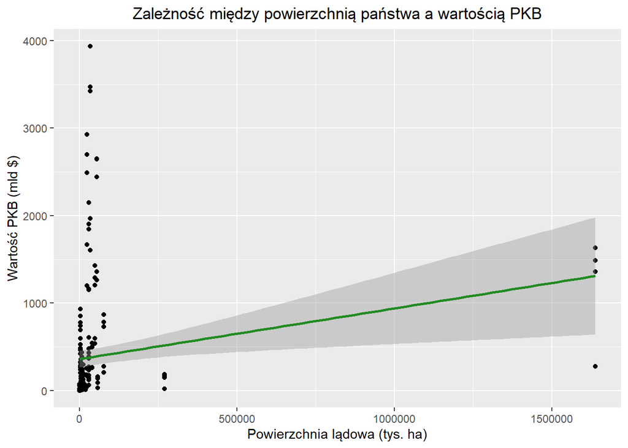

```r
ggplot(forest_gdp_db, aes(x = `TLAXX`, y = `GDP`)) +
  geom_point() +
  geom_smooth(method = "lm", col = "forestgreen", na.rm = TRUE) +
  xlab("Powierzchnia lądowa (tys. ha)") + ylab("Wartość PKB (mld $)") +
  ggtitle("Zależność między powierzchnią państwa a wartością PKB") +
  theme(plot.title = element_text(hjust = 0.5))
```

Widzimy obserwacje odstające, skoro badamy powierzchnię lądową państw, domyślamy się, że tymi obserwacjami są prawdopodobnie Rosja i Kazachstan, dlatego rysujemy wykres bez nich. Dodatkowo poziomymi liniami zaznaczymy kwartyle Q1, Q2 i Q3 dla PKB (**GDP**) i zbadamy też poziom lesistości państw.

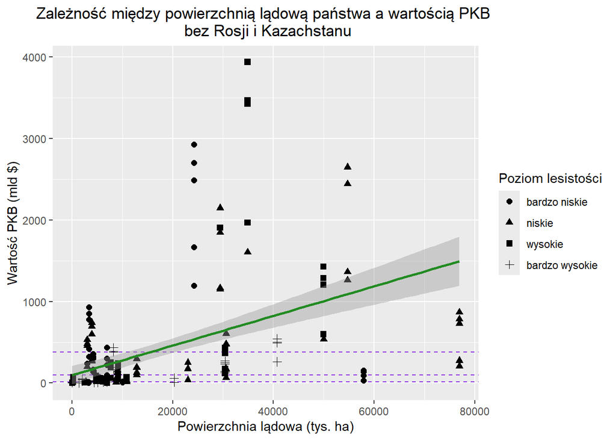

```r
ggplot(forest_gdp_db[forest_gdp_db$Country != "Russian Federation" & forest_gdp_db$Country != "Kazakhstan", ],
       aes(TLAXX, GDP)) +
  geom_hline(yintercept = kwartyle_GDP, col = "blueviolet", linetype = "dashed" ) +
  geom_point(aes(shape = PLAS), size = 2) +
  geom_smooth(method = "lm", col = "forestgreen", na.rm = T) +
  xlab("Powierzchnia lądowa (tys. ha)") + ylab("Wartość PKB (mld $)") +
  ggtitle("Zależność między powierzchnią lądową państwa a wartością PKB \n bez Rosji i Kazachstanu") +
  theme(plot.title = element_text(hjust = 0.5)) +
  labs(shape = "Poziom lesistości")
```

Wraz ze wzrostem powierzchni państwa widzimy, że wzrasta PKB. Państwa o dużej powierzchni lądowej mają raczej niski procent powierzchni leśnej. Większość państw ma małą powierzchnię lądową i niski poziom PKB. Poziome linie reprezentują kwartyle: Q1, Q2, Q3 wartości PKB, czyli ponad 75% obserwacji ma wartość PKB mniejszą niż 500 mld $.

Wyróżnimy teraz 5 państw europejskich - Niemcy, Polskę, Francję, Włochy i Austrię, aby sprawdzić, gdzie znajdują się na naszym wykresie porównującym powierzchnię lądową państwa z wartością PKB. Z wykresu wykluczone zostały Rosja i Kazachstan, żeby nie utrudniały analizy wizualizacji.

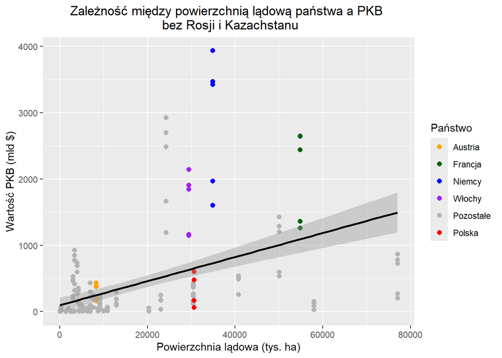

```r
highlight <- c("Germany", "Poland", "France", "Italy", "Austria")

df_plot <- forest_gdp_db %>%
  filter(Country != "Russian Federation",
         Country != "Kazakhstan") %>%
  mutate(highlight_country = ifelse(Country %in% highlight, Country, "Other"))

ggplot(df_plot, aes(TLAXX, GDP, color = highlight_country)) +
  geom_point(size = 2) +
  geom_smooth(method = "lm", color = "black", na.rm = T) +
  scale_color_manual(values = c(
    "Germany" = "blue",
    "Poland" = "red",
    "France" = "darkgreen",
    "Italy" = "purple",
    "Austria" = "orange",
    "Other" = "grey70"
  ),
  labels = c(
    "Germany" = "Niemcy",
    "Poland" = "Polska",
    "France" = "Francja",
    "Italy" = "Włochy",
    "Austria" = "Austria",
    "Other" = "Pozostałe"
    )) +
  labs(color = "Państwo") +
  xlab("Powierzchnia lądowa (tys. ha)") + ylab("Wartość PKB (mld $)") +
  ggtitle("Zależność między powierzchnią lądową państwa a PKB \n bez Rosji i Kazachstanu") +
  theme(plot.title = element_text(hjust = 0.5))
```

Niemcy charakteryzują się wysokim PKB przy umiarkowanej powierzchni, wyraźnie odstając w górę względem większości krajów. Potwierdza to bardzo wysoki poziom rozwoju gospodarczego niezależny od wielkości terytorium. Z kolei Francja łączy relatywnie dużą skalę terytorialną z silną gospodarką. Włochy osiągają wysokie PKB mimo mniejszej powierzchni niż Francja czy Niemcy, co wskazuje na wysoką intensywność gospodarczą i efektywność ekonomiczną. Austria ma niewielką powierzchnię i niższe PKB, jednak wciąż wypada lepiej niż wiele krajów o podobnej skali terytorialnej, co sugeruje stabilny, choć mniejszy potencjał gospodarczy. Za to Polska zajmuje pozycję pośrednią - przy średniej powierzchni osiąga umiarkowane wartości PKB, wyraźnie niższe niż największe gospodarki Europy Zachodniej.

# Analiza obserwacji odstających

Do analizy obserwacji odstających skorzystamy z Reguły Tukeya, która definiuje obserwację nietypową, gdy jest mniejsza od pierwszego kwartyla o więcej niż k wielokrotności rozstępu kwartylowego lub większa od trzeciego kwartyla o więcej niż k wielokrotności rozstępu kwartylowego. W przypadku tego zbioru danych nie możemy skorzystać z innych metod analizy obserwacji odstających, ponieważ nasze zmienne nie mają rozkładów normalnych ani log-normalnych oraz mamy wiele braków danych.

Analiza obserwacji odstających zostanie przeprowadzona przy użyciu wcześniej zdefiniowanej przez nas funkcji **boxplot_outliers**, która rysuje wykres pudełkowy oraz zaznacza na nim obserwacje odstające, a następnie wypisuje je w tabeli. Pozwala ona również zmienić skalę na logarytmiczną. Użyjemy zaproponowanej przez Tukeya wartości k = 1.5. Wykres pudełkowy z osią po logarytmizacji jest analogiczny z wykresem pudełkowym rysującym zmienną po logarytmizacji.

Powierzchnia lądowa (**TLAXX**)

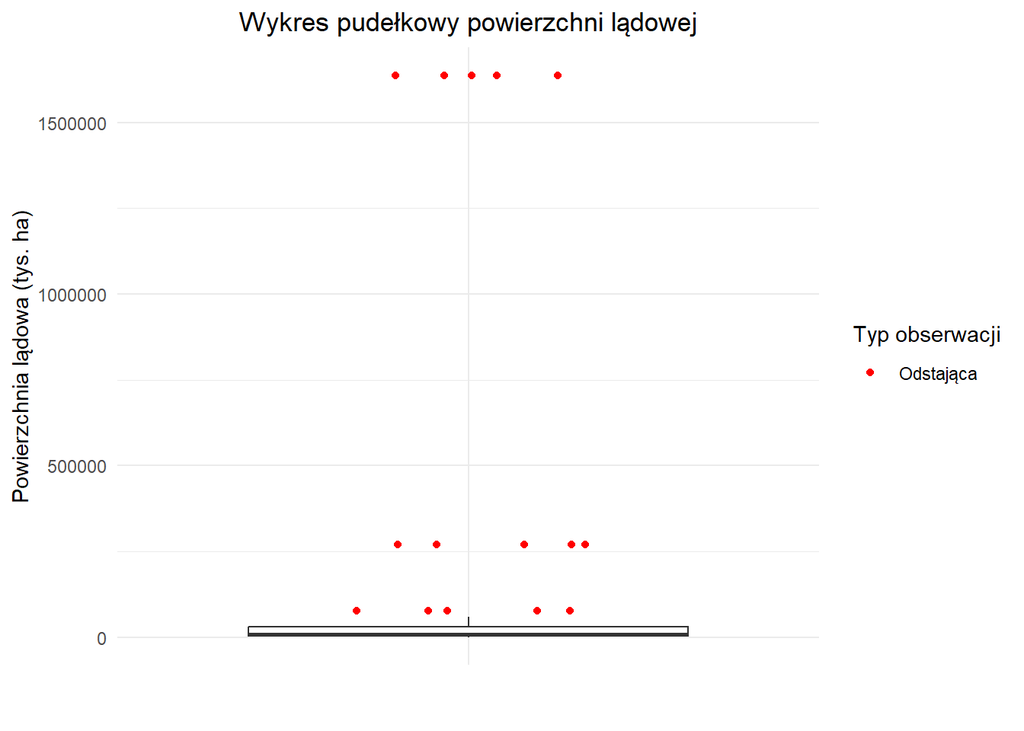

```
## # A tibble: 15 × 12
##    Country    TLAXX AFPTLA  Year Forest_area    GDP  `%GDP`      EFV PRG   PLAS
##    <chr>      <dbl>  <dbl> <dbl>       <dbl>  <dbl>   <dbl>    <dbl> <fct> <fct>
##  1 Kazakhst… 2.70e5   1.17  1990       3162.   NA   0       NA       <NA>  bard…
##  2 Kazakhst… 2.70e5   1.17  2000       3157.   18.3 0.0325   0.00595 nisk… bard…
##  3 Kazakhst… 2.70e5   1.14  2010       3082.  148.  0.00408  0.00604 wyso… bard…
##  4 Kazakhst… 2.70e5   1.23  2015       3308.  184.  0.00367  0.00677 wyso… bard…
##  5 Kazakhst… 2.70e5   1.28  2020       3455.  171.  0.00752  0.0129  wyso… bard…
##  6 Russian … 1.64e6  49.4   1990     808950.   NA   0       NA       <NA>  bard…
##  7 Russian … 1.64e6  49.4   2000     809268.  278.  0.893    2.49    wyso… bard…
##  8 Russian … 1.64e6  49.8   2010     815136. 1633.  0.278    4.54    bard… bard…
##  9 Russian … 1.64e6  49.8   2015     814930. 1357.  0.312    4.23    bard… bard…
## 10 Russian … 1.64e6  49.8   2020     815312. 1488.  0.401    5.97    bard… bard…
## 11 Türkiye   7.70e4  25.7   1990      19783.  208.  0.152    0.316   wyso… nisk…
## 12 Türkiye   7.70e4  26.2   2000      20148.  274.  0.0774   0.212   wyso… nisk…
## 13 Türkiye   7.70e4  27.4   2010      21083.  783.  0.0628   0.491   bard… nisk…
## 14 Türkiye   7.70e4  28.1   2015      21630.  868.  0.0610   0.529   bard… nisk…
## 15 Türkiye   7.70e4  28.9   2020      22220.  730.  0.111    0.811   bard… nisk…
## # ℹ 2 more variables: outlier_linear <lgl>, outlier_color <chr>
```

```r
boxplot_outliers(forest_gdp_db, 'TLAXX', custom_title = "powierzchni lądowej",
                 custom_ylab = "Powierzchnia lądowa (tys. ha)")
```

Widać, że podczas analizy powierzchni lądowej państw występują skrajne obserwacje odstające (powierzchnia Rosji) oraz inne obserwacje odstające. W celu poprawy czytelności zastosujemy skalę logarytmiczną.

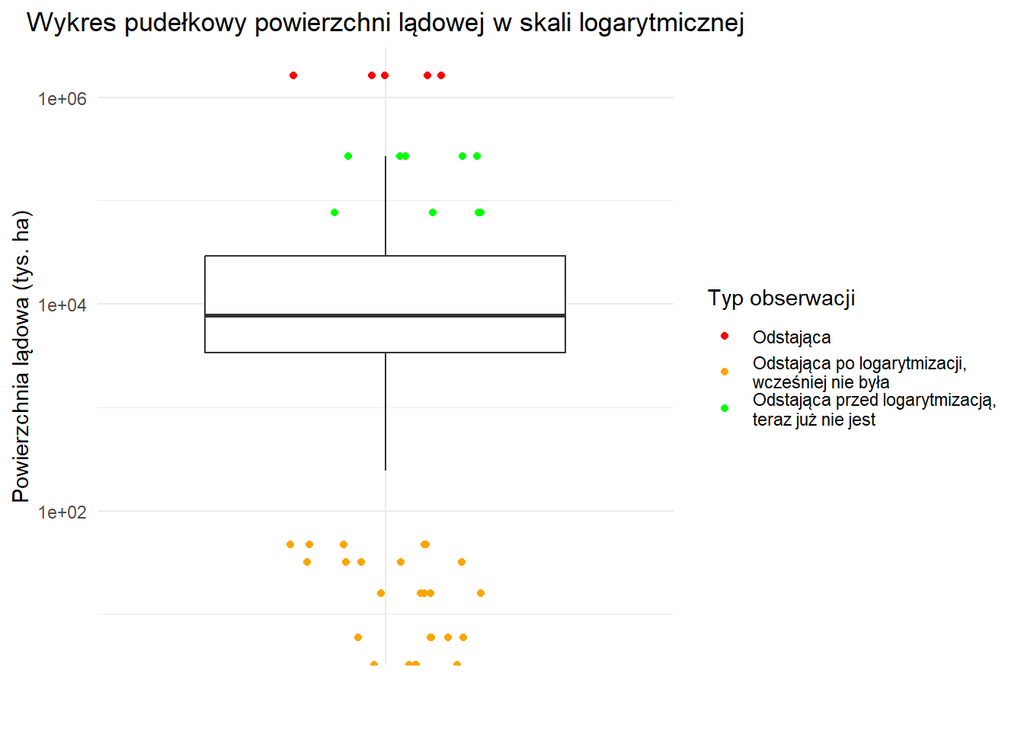

```
## # A tibble: 30 × 13
##    Country     TLAXX AFPTLA  Year Forest_area   GDP  `%GDP`      EFV PRG   PLAS
##    <chr>       <dbl>  <dbl> <dbl>       <dbl> <dbl>   <dbl>    <dbl> <fct> <fct>
##  1 Andorra        47   34.0  1990        16   NA    0       NA       <NA>  wyso…
##  2 Andorra        47   34.0  2000        16    1.43 0        0       bard… wyso…
##  3 Andorra        47   34.0  2010        16    3.45 0        0       bard… wyso…
##  4 Andorra        47   34.0  2015        16    2.79 0        0       bard… wyso…
##  5 Andorra        47   34.0  2020        16    2.88 0        0       bard… wyso…
##  6 Liechtenst…    16   40.6  1990         6.5 NA    0       NA       <NA>  bard…
##  7 Liechtenst…    16   41.9  2000         6.7  2.70 0.00936  2.53e-4 bard… bard…
##  8 Liechtenst…    16   41.9  2010         6.7  5.50 0.00924  5.09e-4 bard… bard…
##  9 Liechtenst…    16   41.9  2015         6.7  6.27 0.00194  1.22e-4 bard… bard…
## 10 Liechtenst…    16   41.9  2020         6.7  6.40 0.00147  9.42e-5 bard… bard…
## # ℹ 20 more rows
## # ℹ 3 more variables: outlier_linear <lgl>, outlier_color <chr>,
## #   outlier_log <lgl>
```

```r
boxplot_outliers(forest_gdp_db, 'TLAXX', log_scale = TRUE,
                 custom_title = "powierzchni lądowej w skali logarytmicznej",
                 custom_ylab = "Powierzchnia lądowa (tys. ha)")
```

Po logarytmizacji, część obserwacji odstających przestaje nimi być, ale niestety mamy nowe, ponieważ niektóre mają tak małą powierzchnię, że w naszej bazie część z nich przyjmuje wartość 0, zatem gdybyśmy wykonali logarytmizację zmiennej otrzymalibyśmy wartość $-\infty$ (punkty przycięte). Nowe obserwacje odstające powstają, ponieważ wartość jest bardzo mała.

Procentowy udział powierzchni leśnej względem lądowej (**AFPTLA**)

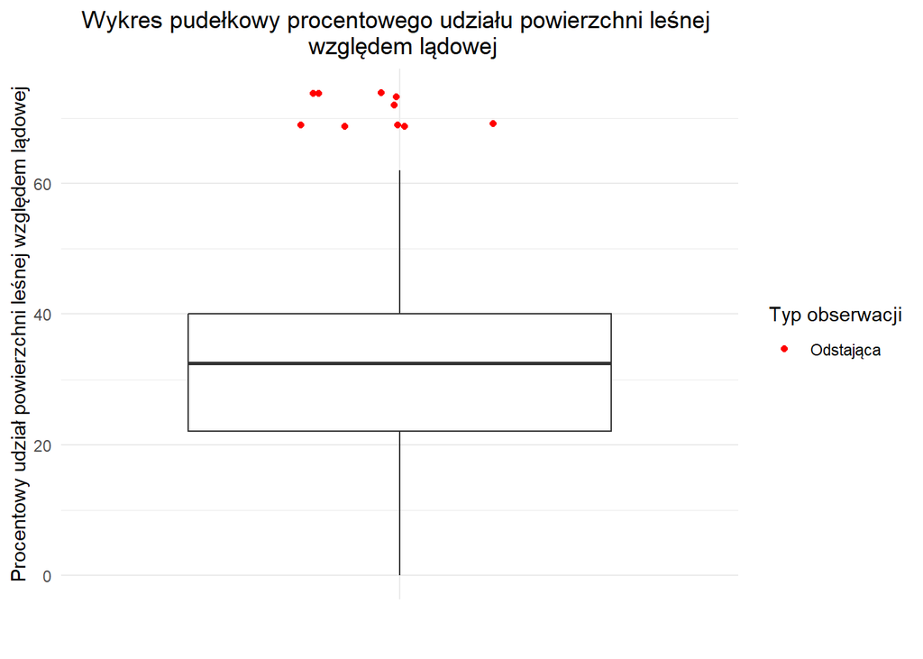

```
## # A tibble: 10 × 12
##    Country TLAXX AFPTLA  Year Forest_area   GDP `%GDP`   EFV PRG           PLAS
##    <chr>   <dbl>  <dbl> <dbl>       <dbl> <dbl>  <dbl> <dbl> <fct>         <fct>
##  1 Finland 30391   72.0  1990      21875.  142.  0.439 0.622 wysokie       bard…
##  2 Finland 30391   73.9  2000      22446.  126.  0.405 0.510 wysokie       bard…
##  3 Finland 30391   73.2  2010      22242   250.  0.322 0.805 wysokie       bard…
##  4 Finland 30391   73.7  2015      22409   233.  0.347 0.809 wysokie       bard…
##  5 Finland 30391   73.7  2020      22409   270.  0.254 0.686 wysokie       bard…
##  6 Sweden  40731   68.9  1990      28063   259.  0.338 0.878 wysokie       bard…
##  7 Sweden  40731   69.1  2000      28163   263.  0.245 0.645 wysokie       bard…
##  8 Sweden  40731   68.9  2010      28073   493.  0.239 1.18  bardzo wysok… bard…
##  9 Sweden  40731   68.7  2015      27980   502.  0.215 1.08  bardzo wysok… bard…
## 10 Sweden  40731   68.7  2020      27980   544.  0.180 0.980 bardzo wysok… bard…
## # ℹ 2 more variables: outlier_linear <lgl>, outlier_color <chr>
```

```r
boxplot_outliers(forest_gdp_db, 'AFPTLA',
          custom_title = "procentowego udziału powierzchni leśnej \n względem lądowej",
          custom_ylab = "Procentowy udział powierzchni leśnej względem lądowej")
```

Mediana procentowego udziału powierzchni leśnej względem lądowej (**AFPTLA**) znajduje się w okolicach 30-35%. Rozstęp międzykwartylowy obejmuje mniej więcej zakres 22-40%, wskazując na umiarkowane zróżnicowanie lesistości między większością państw. Wąsy rozciągają się od bardzo niskich wartości (blisko 0%) do około 60%, co pokazuje szeroki zakres typowych obserwacji. Widać obserwacje odstające występujące po stronie wysokich wartości, co oznacza kraje o wyjątkowo wysokiej lesistości, zatem wykonamy logarytmizację.

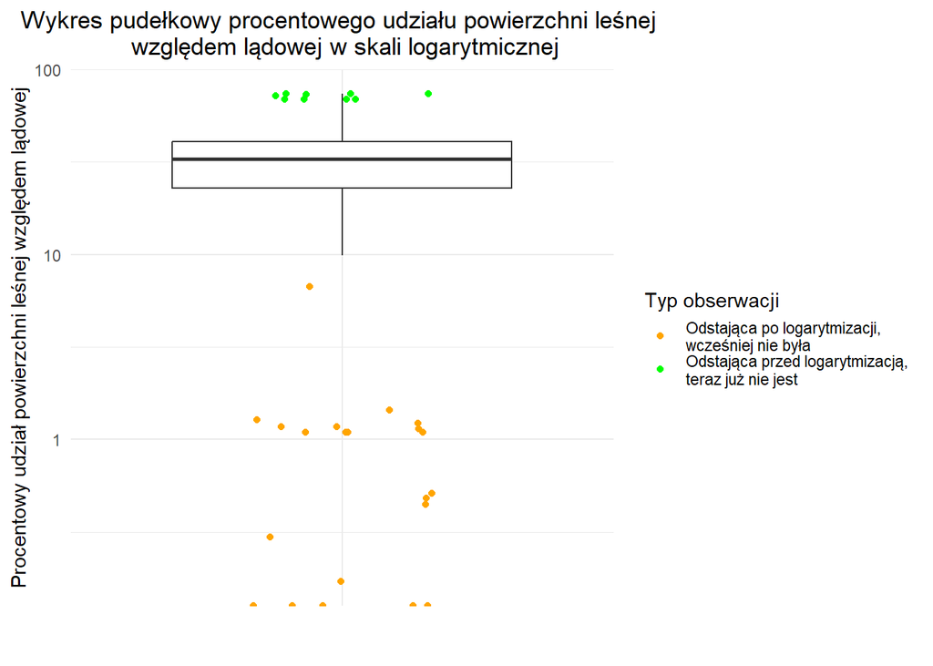

```
## # A tibble: 21 × 13
##    Country    TLAXX AFPTLA  Year Forest_area    GDP  `%GDP`      EFV PRG   PLAS
##    <chr>      <dbl>  <dbl> <dbl>       <dbl>  <dbl>   <dbl>    <dbl> <fct> <fct>
##  1 Iceland    10025  0.170  1990        17.1   6.50 0        0       bard… bard…
##  2 Iceland    10025  0.298  2000        29.8   9.14 0        0       bard… bard…
##  3 Iceland    10025  0.446  2010        44.7  13.9  0        0       bard… bard…
##  4 Iceland    10025  0.480  2015        48.2  17.7  3.00e-4  5.30e-5 nisk… bard…
##  5 Iceland    10025  0.512  2020        51.4  22.0  1.09e-4  2.40e-5 nisk… bard…
##  6 Ireland     6889  6.70   1990       462.   48.2  5.63e-2  2.71e-2 nisk… bard…
##  7 Kazakhst… 269970  1.17   1990      3162.   NA    0       NA       <NA>  bard…
##  8 Kazakhst… 269970  1.17   2000      3157.   18.3  3.25e-2  5.95e-3 nisk… bard…
##  9 Kazakhst… 269970  1.14   2010      3082.  148.   4.08e-3  6.04e-3 wyso… bard…
## 10 Kazakhst… 269970  1.23   2015      3308.  184.   3.67e-3  6.77e-3 wyso… bard…
## # ℹ 11 more rows
## # ℹ 3 more variables: outlier_linear <lgl>, outlier_color <chr>,
## #   outlier_log <lgl>
```

```r
boxplot_outliers(forest_gdp_db, 'AFPTLA', log_scale = TRUE,
                 custom_title = "procentowego udziału powierzchni leśnej \n względem lądowej w skali logarytmicznej",
                 custom_ylab = "Procentowy udział powierzchni leśnej względem lądowej")
```

Obserwacje odstające występujące wcześniej zostały zlikwidowane, jednak pojawiły się nowe.

Rok (**Year**)

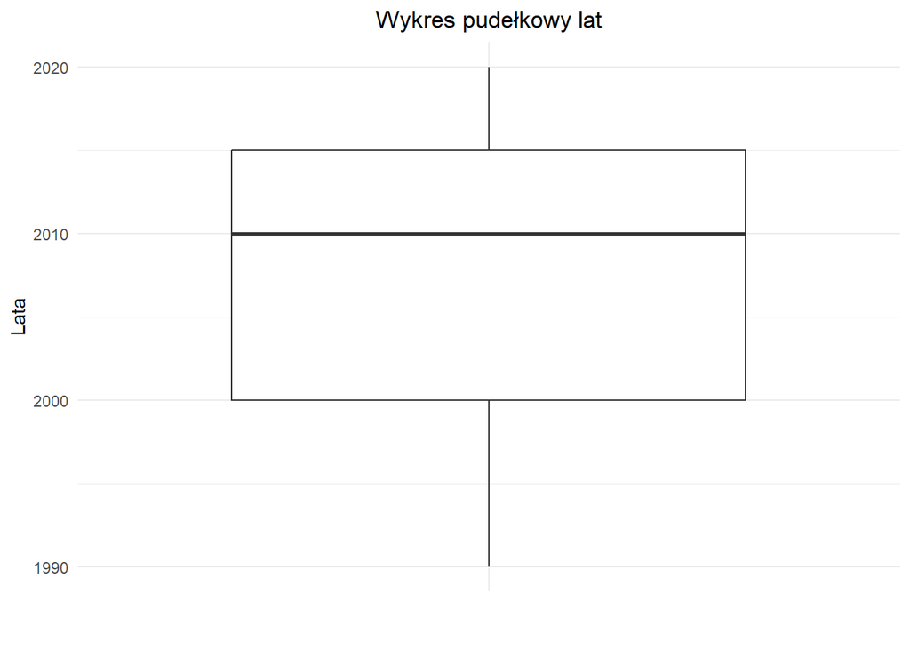

```r
boxplot_outliers(forest_gdp_db, 'Year', print_table = FALSE,
                 custom_title = "lat",
                 custom_ylab = "Lata")
```

Rok (**Year**) nie ma obserwacji odstających, zatem nie ma potrzeby, aby dokonywać przekształceń tej zmiennej.

Powierzchnia leśna (**Forest_area**)

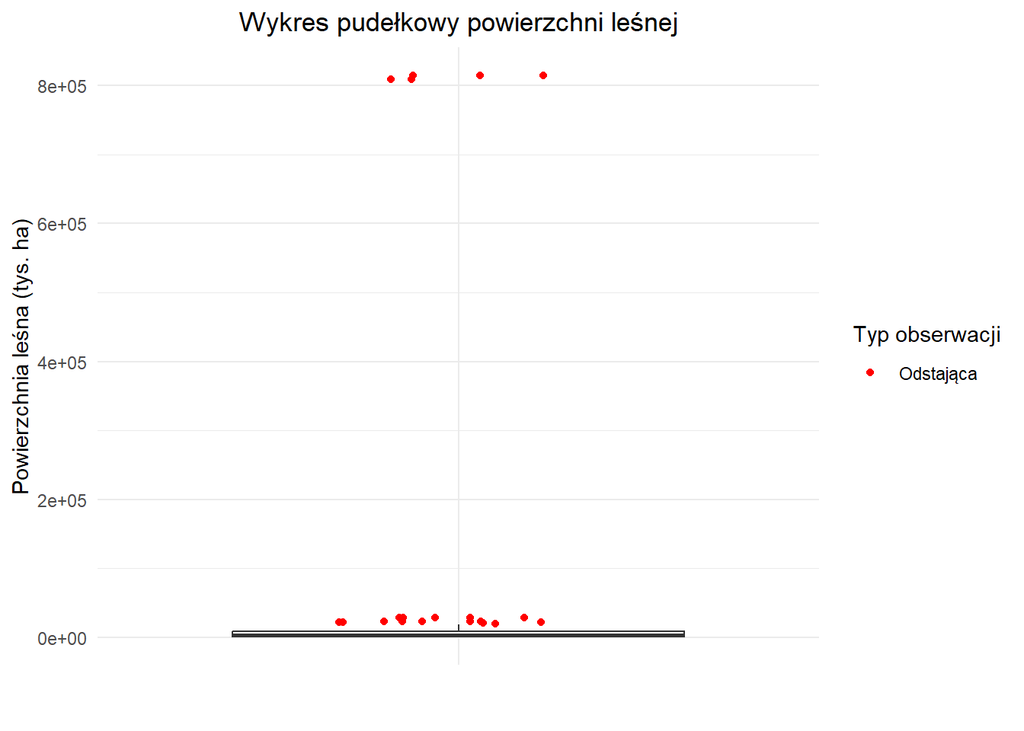

```
## # A tibble: 20 × 12
##    Country        TLAXX AFPTLA  Year Forest_area   GDP `%GDP`    EFV PRG   PLAS
##    <chr>          <dbl>  <dbl> <dbl>       <dbl> <dbl>  <dbl>  <dbl> <fct> <fct>
##  1 Finland       3.04e4   72.0  1990      21875.  142. 0.439   0.622 wyso… bard…
##  2 Finland       3.04e4   73.9  2000      22446.  126. 0.405   0.510 wyso… bard…
##  3 Finland       3.04e4   73.2  2010      22242   250. 0.322   0.805 wyso… bard…
##  4 Finland       3.04e4   73.7  2015      22409   233. 0.347   0.809 wyso… bard…
##  5 Finland       3.04e4   73.7  2020      22409   270. 0.254   0.686 wyso… bard…
##  6 Russian Fede… 1.64e6   49.4  1990     808950.   NA  0      NA     <NA>  bard…
##  7 Russian Fede… 1.64e6   49.4  2000     809268.  278. 0.893   2.49  wyso… bard…
##  8 Russian Fede… 1.64e6   49.8  2010     815136. 1633. 0.278   4.54  bard… bard…
##  9 Russian Fede… 1.64e6   49.8  2015     814930. 1357. 0.312   4.23  bard… bard…
## 10 Russian Fede… 1.64e6   49.8  2020     815312. 1488. 0.401   5.97  bard… bard…
## 11 Sweden        4.07e4   68.9  1990      28063   259. 0.338   0.878 wyso… bard…
## 12 Sweden        4.07e4   69.1  2000      28163   263. 0.245   0.645 wyso… bard…
## 13 Sweden        4.07e4   68.9  2010      28073   493. 0.239   1.18  bard… bard…
## 14 Sweden        4.07e4   68.7  2015      27980   502. 0.215   1.08  bard… bard…
## 15 Sweden        4.07e4   68.7  2020      27980   544. 0.180   0.980 bard… bard…
## 16 Türkiye       7.70e4   25.7  1990      19783.  208. 0.152   0.316 wyso… nisk…
## 17 Türkiye       7.70e4   26.2  2000      20148.  274. 0.0774  0.212 wyso… nisk…
## 18 Türkiye       7.70e4   27.4  2010      21083.  783. 0.0628  0.491 bard… nisk…
## 19 Türkiye       7.70e4   28.1  2015      21630.  868. 0.0610  0.529 bard… nisk…
## 20 Türkiye       7.70e4   28.9  2020      22220.  730. 0.111   0.811 bard… nisk…
## # ℹ 2 more variables: outlier_linear <lgl>, outlier_color <chr>
```

```r
boxplot_outliers(forest_gdp_db, 'Forest_area',
                 custom_title = "powierzchni leśnej",
                 custom_ylab = "Powierzchnia leśna (tys. ha)")
```

Wykres powierzchni leśnej jest nieczytelny, widać skrajne wartości najprawdopodobniej dla Rosji, która ma dużą powierzchnię lasów oraz inne obserwacje odstające, ale zdecydowanie bliższe wąsom. W celu poprawy czytelności zastosujemy skalę logarytmiczną.

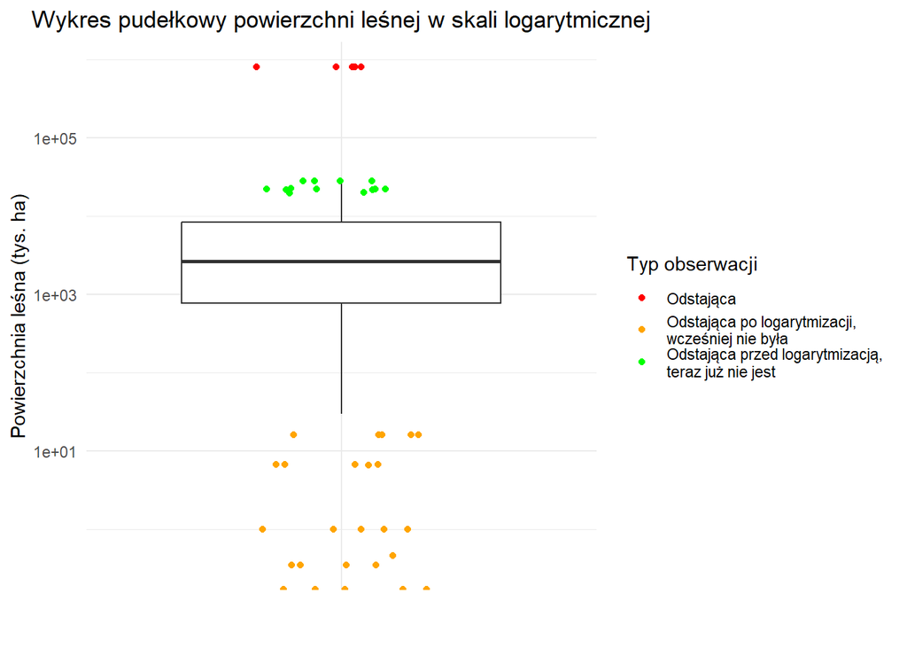

```
## # A tibble: 30 × 13
##    Country     TLAXX AFPTLA  Year Forest_area   GDP  `%GDP`      EFV PRG   PLAS
##    <chr>       <dbl>  <dbl> <dbl>       <dbl> <dbl>   <dbl>    <dbl> <fct> <fct>
##  1 Andorra        47   34.0  1990        16   NA    0       NA       <NA>  wyso…
##  2 Andorra        47   34.0  2000        16    1.43 0        0       bard… wyso…
##  3 Andorra        47   34.0  2010        16    3.45 0        0       bard… wyso…
##  4 Andorra        47   34.0  2015        16    2.79 0        0       bard… wyso…
##  5 Andorra        47   34.0  2020        16    2.88 0        0       bard… wyso…
##  6 Liechtenst…    16   40.6  1990         6.5 NA    0       NA       <NA>  bard…
##  7 Liechtenst…    16   41.9  2000         6.7  2.70 0.00936  2.53e-4 bard… bard…
##  8 Liechtenst…    16   41.9  2010         6.7  5.50 0.00924  5.09e-4 bard… bard…
##  9 Liechtenst…    16   41.9  2015         6.7  6.27 0.00194  1.22e-4 bard… bard…
## 10 Liechtenst…    16   41.9  2020         6.7  6.40 0.00147  9.42e-5 bard… bard…
## # ℹ 20 more rows
## # ℹ 3 more variables: outlier_linear <lgl>, outlier_color <chr>,
## #   outlier_log <lgl>
```

```r
boxplot_outliers(forest_gdp_db, 'Forest_area', log_scale = TRUE,
                 custom_title = "powierzchni leśnej w skali logarytmicznej",
                 custom_ylab = "Powierzchnia leśna (tys. ha)")
```

Po logarytmizacji, część obserwacji odstających przestaje nimi być, niestety mamy nowe obserwacje odstające.

PKB (**GDP**)

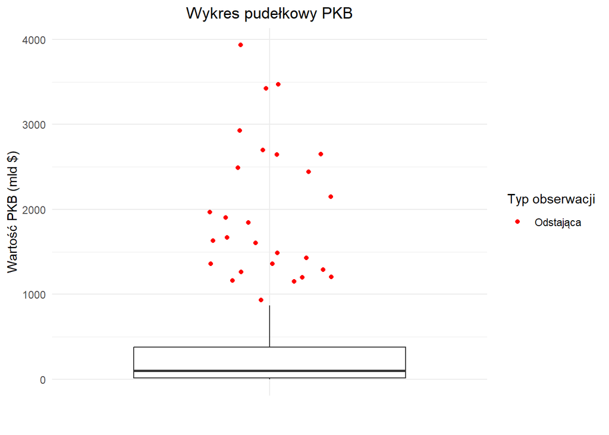

```
## # A tibble: 27 × 12
##    Country TLAXX AFPTLA  Year Forest_area   GDP `%GDP`   EFV PRG           PLAS
##    <chr>   <dbl>  <dbl> <dbl>       <dbl> <dbl>  <dbl> <dbl> <fct>         <fct>
##  1 France  54756   26.4  1990       14436 1261. 0.0687 0.866 bardzo wysok… nisk…
##  2 France  54756   27.9  2000       15288 1362. 0.0531 0.723 bardzo wysok… nisk…
##  3 France  54756   30.0  2010       16419 2648. 0.0420 1.11  bardzo wysok… nisk…
##  4 France  54756   30.7  2015       16836 2443. 0.0358 0.874 bardzo wysok… nisk…
##  5 France  54756   31.5  2020       17253 2646. 0.0233 0.617 bardzo wysok… nisk…
##  6 Germany 34886   32.4  1990       11300 1604. 0.0889 1.43  bardzo wysok… nisk…
##  7 Germany 34886   32.5  2000       11354 1968. 0.0361 0.711 bardzo wysok… wyso…
##  8 Germany 34886   32.7  2010       11409 3470. 0.0437 1.52  bardzo wysok… wyso…
##  9 Germany 34886   32.7  2015       11419 3425. 0.0354 1.21  bardzo wysok… wyso…
## 10 Germany 34886   32.7  2020       11419 3938. 0.0279 1.10  bardzo wysok… wyso…
## # ℹ 17 more rows
## # ℹ 2 more variables: outlier_linear <lgl>, outlier_color <chr>
```

```r
boxplot_outliers(forest_gdp_db, 'GDP',
                 custom_title = "PKB",
                 custom_ylab = "Wartość PKB (mld $)")
```

Widać, że podczas analizy wartości PKB otrzymaliśmy wiele obserwacji odstających w tym skrajne. W celu poprawy czytelności zastosujemy skalę logarytmiczną.

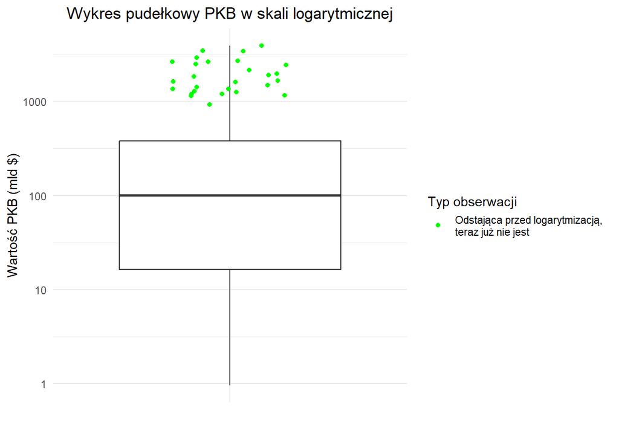

```r
boxplot_outliers(forest_gdp_db, 'GDP', log_scale = TRUE, print_table = FALSE,
                 custom_title = "PKB w skali logarytmicznej",
                 custom_ylab = "Wartość PKB (mld $)")
```

Po logarytmizacji, wszystkie obserwacje odstające przestają nimi być, zatem warto się zastanowić nad zastosowaniem nowej zmiennej **log(GDP)** w modelu.

Procentowy udział gospodarki leśnej w PKB (**%GDP**)

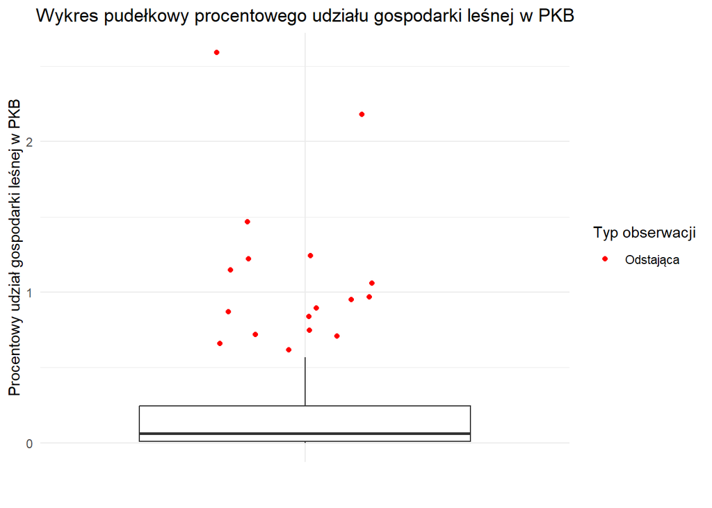

```
## # A tibble: 17 × 12
##    Country       TLAXX AFPTLA  Year Forest_area    GDP `%GDP`    EFV PRG   PLAS
##    <chr>         <dbl>  <dbl> <dbl>       <dbl>  <dbl>  <dbl>  <dbl> <fct> <fct>
##  1 Albania      2.74e3   28.8  1990        789.   2.22  1.47  0.0325 bard… nisk…
##  2 Belarus      2.03e4   40.8  2000       8273   10.8   0.718 0.0774 bard… bard…
##  3 Belarus      2.03e4   42.5  2015       8634.  56.3   0.709 0.399  nisk… bard…
##  4 Belarus      2.03e4   43.2  2020       8768.  61.3   1.15  0.704  nisk… bard…
##  5 Bosnia and … 5.12e3   41.2  2000       2112.   5.57  1.06  0.0590 bard… bard…
##  6 Estonia      4.35e3   51.5  2000       2239.   5.71  2.18  0.124  bard… bard…
##  7 Estonia      4.35e3   53.7  2010       2336.  19.6   0.839 0.164  nisk… bard…
##  8 Estonia      4.35e3   55.7  2015       2421.  23.3   0.868 0.202  nisk… bard…
##  9 Estonia      4.35e3   56.1  2020       2438.  31.8   0.949 0.302  nisk… bard…
## 10 Latvia       6.22e3   52.1  2000       3241    7.76  2.59  0.201  bard… bard…
## 11 Latvia       6.22e3   54.2  2010       3372.  23.5   1.22  0.287  nisk… bard…
## 12 Latvia       6.22e3   54.5  2015       3391.  26.3   0.969 0.255  nisk… bard…
## 13 Latvia       6.22e3   54.9  2020       3411.  33.4   1.24  0.415  nisk… bard…
## 14 Lithuania    6.27e3   32.2  2000       2020   11.5   0.657 0.0759 bard… nisk…
## 15 Montenegro   1.34e3   61.5  2020        827    4.73  0.616 0.0291 bard… bard…
## 16 Romania      2.30e4   27.7  1990       6371   38.5   0.748 0.288  nisk… nisk…
## 17 Russian Fed… 1.64e6   49.4  2000     809268. 278.    0.893 2.49   wyso… bard…
## # ℹ 2 more variables: outlier_linear <lgl>, outlier_color <chr>
```

```r
boxplot_outliers(forest_gdp_db, "%GDP",
                 custom_title = "procentowego udziału gospodarki leśnej w PKB",
                 custom_ylab = "Procentowy udział gospodarki leśnej w PKB")
```

Widać, że podczas analizy udziału procentowego gospodarki leśnej w PKB otrzymaliśmy skrajne wartości oraz inne obserwacje odstające, ale zdecydowanie bliższe wąsom. Wykres może zostać poprawiony, dlatego zastosujemy skalę logarytmiczną.

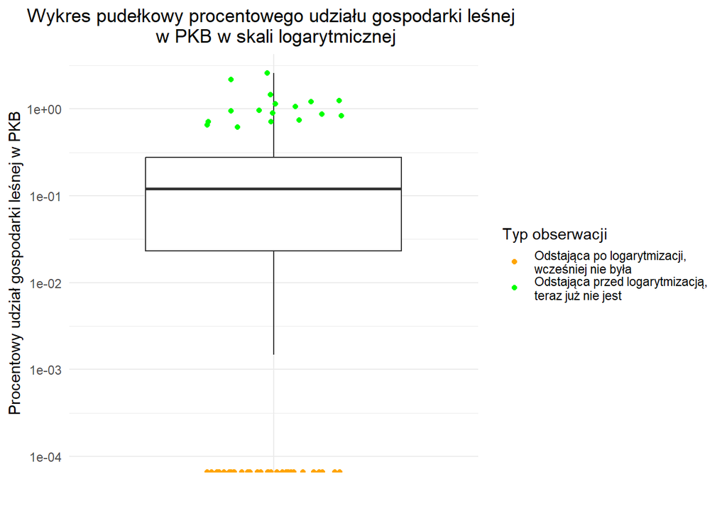

```
## # A tibble: 34 × 13
##    Country  TLAXX AFPTLA  Year Forest_area   GDP `%GDP`   EFV PRG          PLAS
##    <chr>    <dbl>  <dbl> <dbl>       <dbl> <dbl>  <dbl> <dbl> <fct>        <fct>
##  1 Andorra    47  34.0    1990        16   NA         0    NA <NA>         wyso…
##  2 Andorra    47  34.0    2000        16    1.43      0     0 bardzo nisk… wyso…
##  3 Andorra    47  34.0    2010        16    3.45      0     0 bardzo nisk… wyso…
##  4 Andorra    47  34.0    2015        16    2.79      0     0 bardzo nisk… wyso…
##  5 Andorra    47  34.0    2020        16    2.88      0     0 bardzo nisk… wyso…
##  6 Belarus 20298. 38.3    1990      7780   NA         0    NA <NA>         wyso…
##  7 Czechia  7721  34.1    1990      2629.  NA         0    NA <NA>         wyso…
##  8 Georgia  6949  39.6    1990      2752.  NA         0    NA <NA>         wyso…
##  9 Iceland 10025   0.170  1990        17.1  6.50      0     0 bardzo nisk… bard…
## 10 Iceland 10025   0.298  2000        29.8  9.14      0     0 bardzo nisk… bard…
## # ℹ 24 more rows
## # ℹ 3 more variables: outlier_linear <lgl>, outlier_color <chr>,
## #   outlier_log <lgl>
```

```r
boxplot_outliers(forest_gdp_db, "%GDP", log_scale = TRUE,
                 custom_title = "procentowego udziału gospodarki leśnej \n w PKB w skali logarytmicznej",
                 custom_ylab = "Procentowy udział gospodarki leśnej w PKB")
```

Po logarytmizacji, wszystkie obserwacje odstające przestają nimi być, ale pojawiają się nowe. Spowodowane są faktem, iż niektóre kraje mają wartość 0 w procentowym udziale gospodarki leśnej w PKB (**%GDP**).

Wartość gospodarki leśnej (**EFV**)

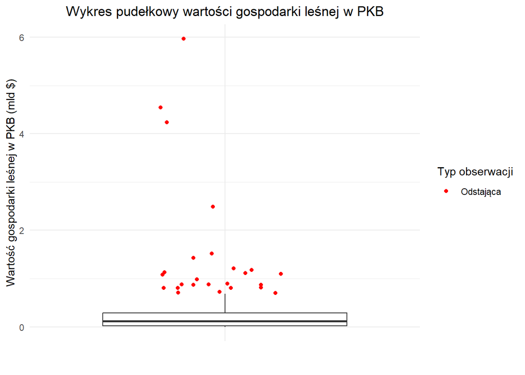

```
## # A tibble: 25 × 12
##    Country  TLAXX AFPTLA  Year Forest_area    GDP `%GDP`   EFV PRG         PLAS
##    <chr>    <dbl>  <dbl> <dbl>       <dbl>  <dbl>  <dbl> <dbl> <fct>       <fct>
##  1 Belarus 20298.   43.2  2020       8768.   61.3 1.15   0.704 niskie      bard…
##  2 Czechia  7721    34.7  2020       2677.  251.  0.355  0.891 wysokie     wyso…
##  3 Finland 30391    73.2  2010      22242   250.  0.322  0.805 wysokie     bard…
##  4 Finland 30391    73.7  2015      22409   233.  0.347  0.809 wysokie     bard…
##  5 France  54756    26.4  1990      14436  1261.  0.0687 0.866 bardzo wys… nisk…
##  6 France  54756    27.9  2000      15288  1362.  0.0531 0.723 bardzo wys… nisk…
##  7 France  54756    30.0  2010      16419  2648.  0.0420 1.11  bardzo wys… nisk…
##  8 France  54756    30.7  2015      16836  2443.  0.0358 0.874 bardzo wys… nisk…
##  9 Germany 34886    32.4  1990      11300  1604.  0.0889 1.43  bardzo wys… nisk…
## 10 Germany 34886    32.5  2000      11354  1968.  0.0361 0.711 bardzo wys… wyso…
## # ℹ 15 more rows
## # ℹ 2 more variables: outlier_linear <lgl>, outlier_color <chr>
```

```r
boxplot_outliers(forest_gdp_db, "EFV",
                 custom_title = "wartości gospodarki leśnej w PKB",
                 custom_ylab = "Wartość gospodarki leśnej w PKB (mld $)")
```

Widać, że podczas analizy wartości gospodarki leśnej otrzymaliśmy skrajne obserwacje odstające oraz inne obserwacje odstające, ale zdecydowanie bliższe wąsom. Wykres może zostać poprawiony, dlatego zastosujemy skalę logarytmiczną.

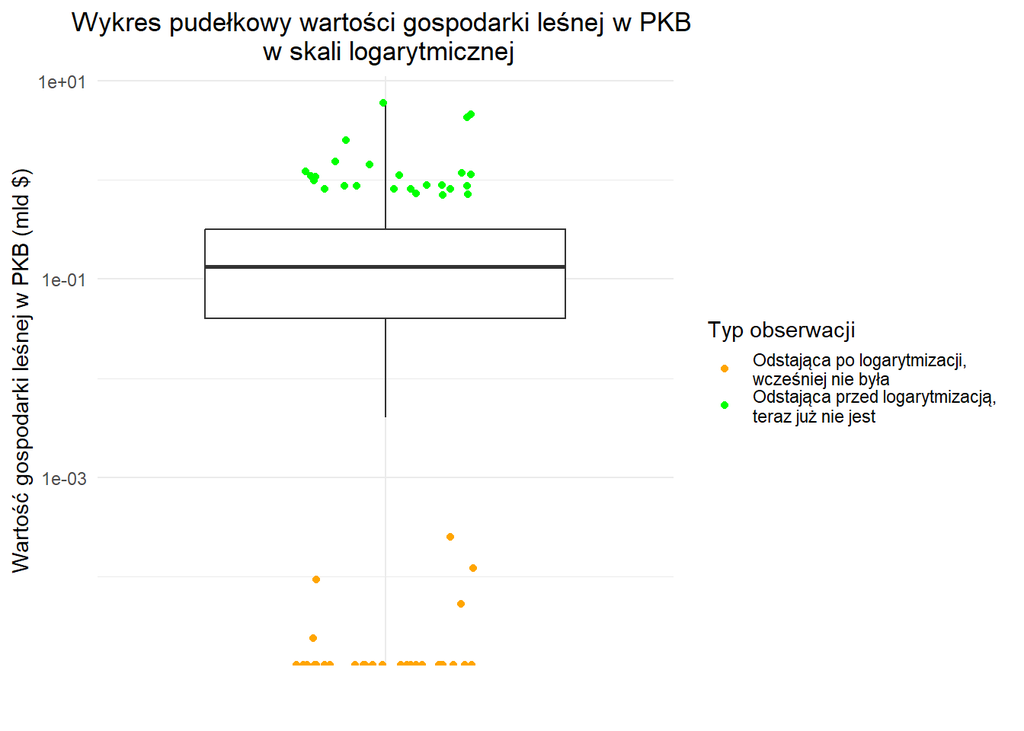

```
## # A tibble: 28 × 13
##    Country      TLAXX AFPTLA  Year Forest_area   GDP  `%GDP`     EFV PRG   PLAS
##    <chr>        <dbl>  <dbl> <dbl>       <dbl> <dbl>   <dbl>   <dbl> <fct> <fct>
##  1 Andorra         47 34.0    2000        16    1.43 0       0       bard… wyso…
##  2 Andorra         47 34.0    2010        16    3.45 0       0       bard… wyso…
##  3 Andorra         47 34.0    2015        16    2.79 0       0       bard… wyso…
##  4 Andorra         47 34.0    2020        16    2.88 0       0       bard… wyso…
##  5 Iceland      10025  0.170  1990        17.1  6.50 0       0       bard… bard…
##  6 Iceland      10025  0.298  2000        29.8  9.14 0       0       bard… bard…
##  7 Iceland      10025  0.446  2010        44.7 13.9  0       0       bard… bard…
##  8 Iceland      10025  0.480  2015        48.2 17.7  3.00e-4 5.30e-5 nisk… bard…
##  9 Iceland      10025  0.512  2020        51.4 22.0  1.09e-4 2.40e-5 nisk… bard…
## 10 Liechtenste…    16 41.9    2000         6.7  2.70 9.36e-3 2.53e-4 bard… bard…
## # ℹ 18 more rows
## # ℹ 3 more variables: outlier_linear <lgl>, outlier_color <chr>,
## #   outlier_log <lgl>
```

```r
boxplot_outliers(forest_gdp_db, "EFV", log_scale = T,
                 custom_title = "wartości gospodarki leśnej w PKB \n w skali logarytmicznej",
                 custom_ylab = "Wartość gospodarki leśnej w PKB (mld $)")
```

Po logarytmizacji, wszystkie obserwacje odstające przestają nimi być. Niestety, pojawiają się nowe obserwacje odstające.

Zostawiamy wszystkie obserwacje odstające, dane są poprawne, ponieważ są to rzeczywiste informacje i obserwacje odstające wynikają z faktycznych danych. Na etapie tworzenia modeli będzie można zastanowić się nad ich usunięciem, np. w modelach liniowych używając wartości Cooka. W dalszej części pracy będzie można dodać zmienne po logarytmizacji, w celu usunięcia pewnych obserwacji odstających.